# Lab 20: Linear Regression

## Instructions

Below you will find several empty R code scripts and answer prompts. Your task is to fill in the required code snippets and answer the corresponding questions.

## Diamonds Data - Simple Regression

Today, we will start by looking at a dataset of diamond prices:

Fit a linear regression predicting the diamond price as a function of its weight (carats). Print out the regression table without any confidence intervals.

```
##
## Call:
## lm_basic(formula = price ~ 1 + carat, data = diamonds)
##
## Residuals:
##      Min       1Q   Median       3Q      Max
## -18585.3   -804.8    -18.9    537.4  12731.7
##
## Coefficients:
##             Estimate
## (Intercept)    -2256
## carat           7756
##
## Residual standard error: 1549 on 53938 degrees of freedom
## Multiple R-squared:  0.8493, Adjusted R-squared:  0.8493
## F-statistic: 3.041e+05 on 1 and 53938 DF,  p-value: < 2.2e-16
```

How would you interpret the slope coefficient in this model?

**Answer**:On average for every carat that is added to the ring the price goes up 7756 dollars.

Next, show the same regression as a scatter plot with a smoothing line:

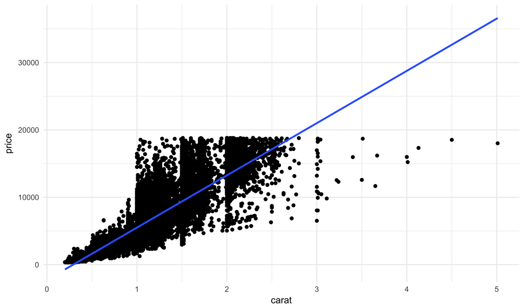

Now, print the same model as in the previous question but add a 95% confidence interval.

```
##
## Call:
## lm_basic(formula = price ~ 1 + carat, data = diamonds)
##
## Residuals:
##      Min       1Q   Median       3Q      Max
## -18585.3   -804.8    -18.9    537.4  12731.7
##
## Coefficients:
##             Estimate 2.5 % 97.5 %
## (Intercept)    -2256 -2282  -2231
## carat           7756  7729   7784
##
## Residual standard error: 1549 on 53938 degrees of freedom
## Multiple R-squared:  0.8493, Adjusted R-squared:  0.8493
## F-statistic: 3.041e+05 on 1 and 53938 DF,  p-value: < 2.2e-16
```

What range of values does the confidence interval give for the intercept in this model?

**Answer**:-2282 to -2231

What range of values does the confidence interval give for the slope in this model?

**Answer**:7729 to 7784

Would you be surprised if we collected another set of diamonds, in exactly the same way as before, and found a slope estimate equal to 5500?

**Answer**:Yes

Would you be surprised if we collected another set of diamonds, in exactly the same way as before, and found a slope estimate equal to 7500?

**Answer**:Yes

The biggest use of confidence intervals, at least for us, is to determine whether the confidence interval for a slope contains only values that are all negative, all positive, or a mix of both.

Why might this be important? Let’s look at our diamond example. Describe the meaning of the slope in this linear regression:

**Answer**:For every carat that is added to the ring the price goes up 7756 dollars on average.

Therefore, if the confidence interval has only positive values, we can fairly confidently say is that there is a positive relationship between diamond weight and its price.

Now, fit a regression model on the diamonds dataset, predicting the price as a function of depth. Compute the regression table using level equal to .95:

```
##
## Call:
## lm_basic(formula = price ~ 1 + depth, data = diamonds)
##
## Residuals:
##    Min     1Q Median     3Q    Max
##  -3766  -2986  -1521   1396  14937
##
## Coefficients:
##             Estimate   2.5 %  97.5 %
## (Intercept)  5763.67 4312.17 7215.16
## depth         -29.65  -53.15   -6.15
##
## Residual standard error: 3989 on 53938 degrees of freedom
## Multiple R-squared:  0.0001134,  Adjusted R-squared:  9.483e-05
## F-statistic: 6.115 on 1 and 53938 DF,  p-value: 0.0134
```

What does the model predict will be the price of a diamond with a depth of 60?

**Answer**:3,984.67

Describe in words the estimate of the slope in terms of the dataset.

**Answer**:For every one unit of increase in depth the value of the diamond value decreases by 29.65.

Using the regression table from the previous question, does the confidence interval contain only values that are positive, only values that are negative, or values that are both positive and negative?

Interpret this in words (your words, not just the formal definition).

## Diamonds Data - Multiple Linear Regression

While we lose the nice graphical summary, it is possible to build linear models with more than one variable and an intercept. In the diamond example, for instance, we can fit a model that has both depth and carat in it:

```
##
## Call:
## lm_basic(formula = price ~ 1 + carat + depth, data = diamonds)
##
## Residuals:
##      Min       1Q   Median       3Q      Max
## -18238.9   -801.6    -19.6    546.3  12683.7
##
## Coefficients:
##             Estimate  2.5 %  97.5 %
## (Intercept)   4045.3 3484.4 4606.30
## carat         7765.1 7737.7 7792.60
## depth         -102.2 -111.3  -93.08
##
## Residual standard error: 1542 on 53937 degrees of freedom
## Multiple R-squared:  0.8507, Adjusted R-squared:  0.8507
## F-statistic: 1.536e+05 on 2 and 53937 DF,  p-value: < 2.2e-16
```

Notice that switching the order of the inputs does not change the estimates or confidence intervals; only the order in the output is modified, but this is inconsequential:

```
##
## Call:
## lm_basic(formula = price ~ 1 + depth + carat, data = diamonds)
##
## Residuals:
##      Min       1Q   Median       3Q      Max
## -18238.9   -801.6    -19.6    546.3  12683.7
##
## Coefficients:
##             Estimate  2.5 %  97.5 %
## (Intercept)   4045.3 3484.4 4606.30
## depth         -102.2 -111.3  -93.08
## carat         7765.1 7737.7 7792.60
##
## Residual standard error: 1542 on 53937 degrees of freedom
## Multiple R-squared:  0.8507, Adjusted R-squared:  0.8507
## F-statistic: 1.536e+05 on 2 and 53937 DF,  p-value: < 2.2e-16
```

Using the model in the previous question, what do you expect will be the price of a diamond with a depth of 50 that weights 2 carats?

Are both of the slopes in the model statistically significant? What are their signs?

**Answer**:Yes and depth is negative while carat is positive

Use the `add_prediction` function to add predictions from this model back into the diamonds dataset.

What is the largest positive residual (you can either use the `max` function or sort the data in the data viewer)?

**Answer**:12683.655

Interpreting the meaning of the slopes in a regression model with multiple variables changes slightly from the version with a single slope. Each slope measures the change in the response give a change in its corresponding value, when holding the other variables in the model fixed. This last part is actually important and we will see some examples that at first seem counterintuitive that make sense once we remember this caveat.

Describe the meaning the slopes, in your own words, in the regression model above.

**Answer**:For every one unit of depth added the price decrease by 102.2 on average. For every one unit of carat that is added to the diamond the price increases by 7765.1 on average.

Notice that we can do some comparisons quickly with the slope estimates. For example, if we have two diamonds with the same depth where one is 1 carat in weight and the other is 2 carats in weight, how much more do you expect the heavier diamond to cost?